# DAT301 Midterm Project

## Income Prediction

### Based on Census Data

UCI’s Machine Learning Repository, Adult Data Set: https://archive.ics.uci.edu/ml/datasets/Adult

- Predicts if income is above or below $50,000 based on census data.
- Extraction was done by Barry Becker taken from 1994 Census database

[figure not shown]

## Categories of Adult Income Data

**age**: continuous.

**workclass**: Private, Self-emp-not-inc, Self-emp-inc, Federal-gov, Local-gov, State-gov, Without-pay, Never-worked.

**fnlwgt**: continuous.

**education**: Bachelors, Some-college, 11th, HS-grad, Prof-school, Assoc-acdm, Assoc-voc, 9th, 7th-8th, 12th, Masters, 1st-4th, 10th, Doctorate, 5th-6th, Preschool.

**education-num**: continuous.

**marital-status**: Married-civ-spouse, Divorced, Never-married, Separated, Widowed, Married-spouse-absent, Married-AF-spouse.

**occupation**: Tech-support, Craft-repair, Other-service, Sales, Exec-managerial, Prof-specialty, Handlers-cleaners, Machine-op-inspct, Adm-clerical, Farming-fishing, Transport-moving, Priv-house-serv, Protective-serv, Armed-Forces.

**relationship**: Wife, Own-child, Husband, Not-in-family, Other-relative, Unmarried.

**race**: White, Asian-Pac-Islander, Amer-Indian-Eskimo, Other, Black.

**sex**: Female, Male.

## Categories of Adult Income Data Continued

**capital-gain**: continuous

**capital-loss**: continuous

**hours-per-week**: continuous.

**native-country**: United-States, Cambodia, England, Puerto-Rico, Canada, Germany, Outlying-US(Guam-USVI-etc), India, Japan, Greece, South, China, Cuba, Iran, Honduras, Philippines, Italy, Poland, Jamaica, Vietnam, Mexico, Portugal, Ireland, France, Dominican-Republic, Laos, Ecuador, Taiwan, Haiti, Columbia, Hungary, Guatemala, Nicaragua, Scotland, Thailand, Yugoslavia, El-Salvador, Trinadad&Tobago, Peru, Hong, Holand-Netherlands.

## Attribute Details

**fnlwgt**:

The number of people one row represents

**marital-status**:

Married-civ-spouse: Married to a civilian

Married-AF-spouse: Married to someone in the Armed Forces

## Motivation

Help us in our own careers.

See historically what attributes people have to increase wage.

[figure not shown]

[figure not shown]

## Challenges

Different characters in the name: Married-civ-spouse has a space in the front

Some values are missing in rows

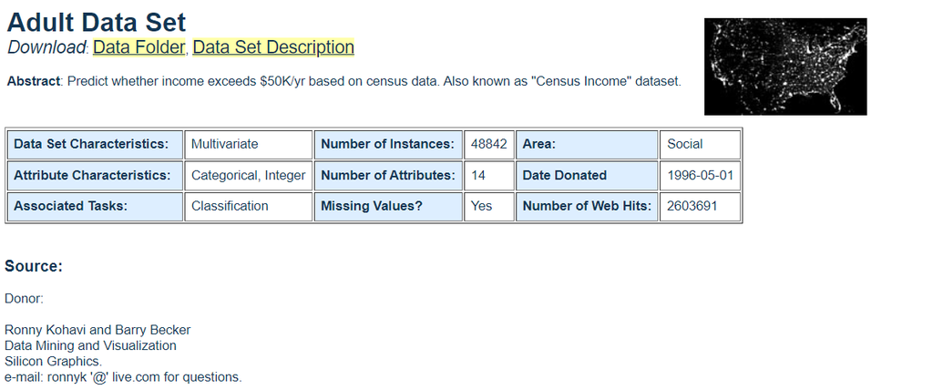

## 1. How many people are there for each education category?

[figure not shown]

## 2. Does the workclass affect if the individual make above or below $50,000 a year?

|  | Private | Self-emp-not-inc | Self-emp-inc | Federal-gov | Local-gov | State-gov | Without-pay | Never-worked |
| --- | --- | --- | --- | --- | --- | --- | --- | --- |
| >50K | 4963 | 724 | 622 | 371 | 617 | 353 | 0 | 0 |
| <=50K | 17733 | 1817 | 494 | 589 | 1476 | 944 | 14 | 7 |

## Barplot

[figure not shown]

## 3. Hours per Week

### Wage above or below $50,000 a year?

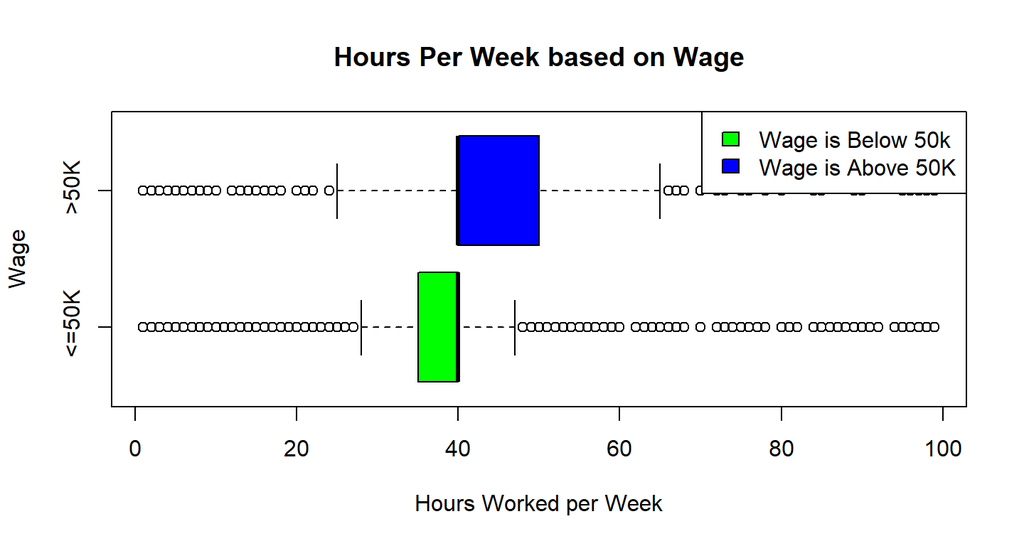

## Analysis

On Average, people that work over 40 hours a week have wages greater than $50,000

## 4. Marital Status

### Does making above or below $50,000 have an impact on marital status?

|  | Married, Civilian Spouse | Divorced | Never Married | Separated | Widowed | Married, Spouse Absent | Married, Armed Forces Spouse |
| --- | --- | --- | --- | --- | --- | --- | --- |
| >50K | 6692 | 463 | 491 | 66 | 85 | 34 | 10 |
| <=50K | 8284 | 3980 | 10191 | 959 | 908 | 384 | 13 |

## Barplot

[figure not shown]

## Analysis

There largest group of people that make over $50,000 are married.

The largest group of people that make under $50,000 have never been married.

## 5. Gender

### Does gender have an effect on wages?

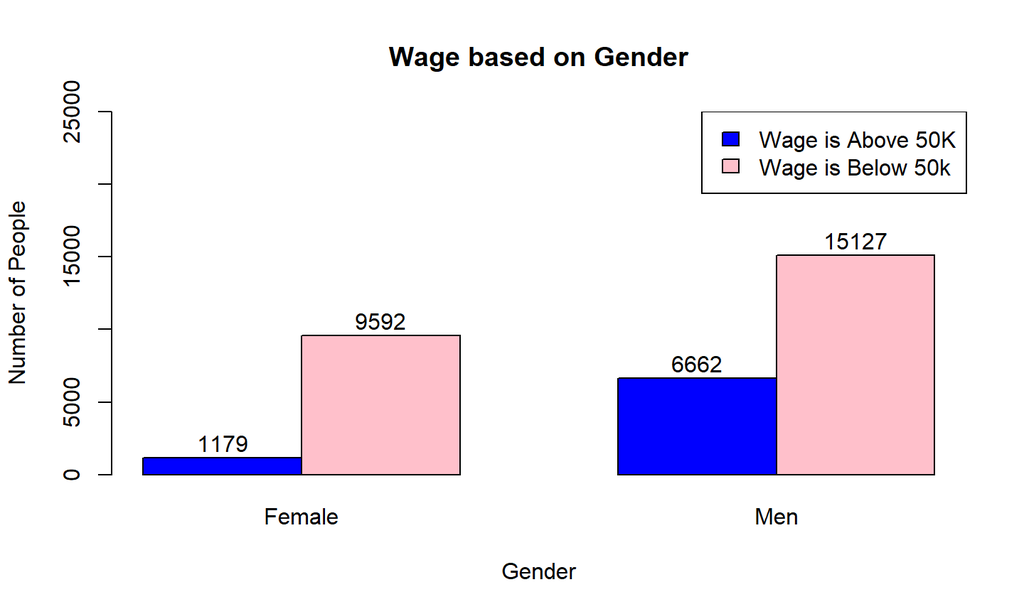

## Analysis

Based on population of data, this shows a significant discrepency on gender-pay ratios.

## 6. Hours per Week

### Does the hours per week affect marital status?

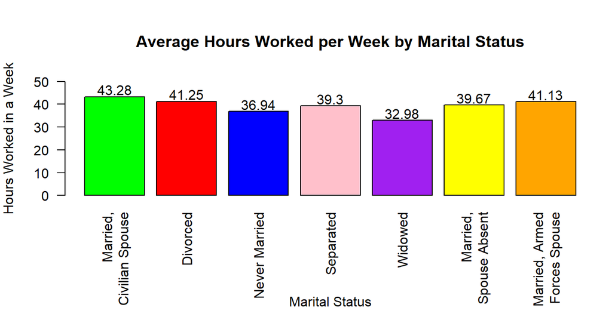

## Analysis

Based off the bar graph, people married work the most hours.

Widowed individuals seem to have the lowest hours worked per week. This can be due a variety of reasons, most likely due to increased familial obligations.

## 7. Education

### Does education affect wage?

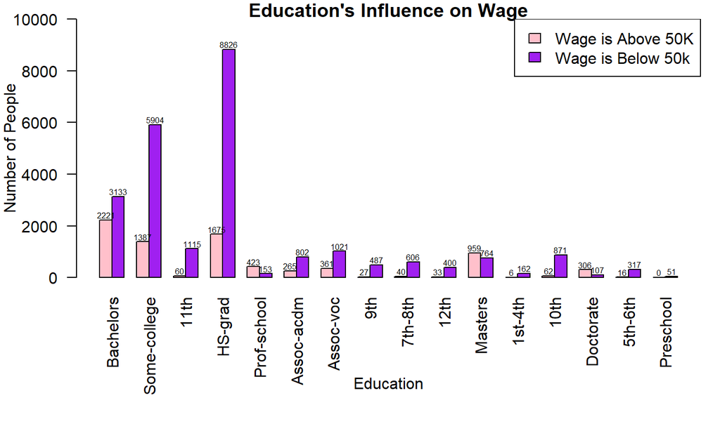

## Analysis

Most people with Bachelor’s degrees are making less than $50,000 a year while most people with Master’s degrees are making more than $50,000 a year.

Most High School graduates make less than $50,000 a year.

## 8. Occupation

### Hours per Week by Occupation

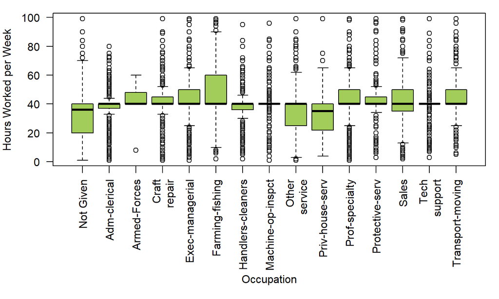

## Analysis

Most occupations had a mean that steadied around 40 hours/week.